# VL05: Constraints: Backtracking, Heuristiken, AC-3

IFM 5.6 Künstliche Intelligenz, 2017/18

Carsten Gips, FH Bielefeld

# Wiederholung

## Eigenschaften von Minimax

- Wie verhält sich der Minimax-Algorithmus, wenn `MIN` suboptimal spielt?
- Wie kann man mit Minimax Spiele mit mehreren Spielern spielen?
- Was bedeutet “alpha-beta-Pruning”?

# Motivation

## Motivation: Einfärben von Landkarten

Quelle: [AIMA 3rd ed.](http://aima.cs.berkeley.edu)

## Einfärben von Landkarten (Lösung)

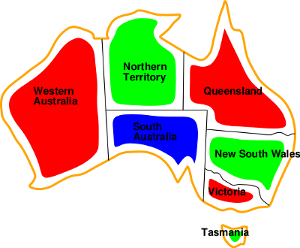

Quelle: [AIMA 3rd ed.](http://aima.cs.berkeley.edu)

## Themen für heute

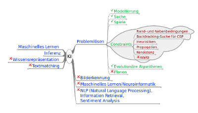

Am Ende der VL können/verstehen Sie:

- Was sind Constraints?
- Wie kann man Constraint-Probleme lösen?
- Wie kann man die Suche verbessern (Heuristiken)?

# Einführung Constraints

## Einfärben von Landkarten: Formalisierung

Quelle: [AIMA 3rd ed.](http://aima.cs.berkeley.edu)

- **Variablen**: WA, NT, SA, Q, NSW, V, T
- **Werte**: $\left\{red, green, blue\right\}$
- **Constraints**: Benachbarte Regionen müssen unterschiedliche Farben haben

## Einfärben von Landkarten: Lösung

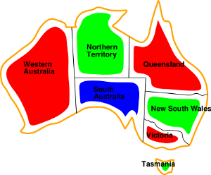

Quelle: [AIMA 3rd ed.](http://aima.cs.berkeley.edu)

**Mögliche Lösung**: $\{\operatorname{WA} = red , \operatorname{NT} = green, \operatorname{Q} = red , \operatorname{NSW} = green, \operatorname{V} = red , \operatorname{SA} = blue, \operatorname{T} = green\}$

## Definition: Constraint Satisfaction Problem (CSP)

- Ein CSP $\langle V, D, C \rangle$ besteht aus:
  - Menge von **Variablen** $V = \{V_1, V_2, \ldots, V_n\}$
  - Je $V_i$ nicht leere **Domäne** $D_i = \{d_{i,1}, d_{i,2}, \ldots, d_{i,m_i}\}$
  - Menge von **Constraints** $C = \{C_1, C_2, \ldots, C_p\}$(Randbedingungen, Abhängigkeiten zwischen Variablen)
- Zuweisung/Belegung (*Assignment*) $\alpha$:
  - Zuweisung von Werten an (einige/alle) Variablen: $\alpha = \{X=a, Y=b, \ldots\}$ (aus den jeweiligen Wertebereichen)
  - **Konsistente Belegung**: Randbedingungen sind nicht verletzt
  - **Vollständige Belegung**: Alle Variablen sind belegt
- **Lösung** eines CSP: Vollständige und konsistente Belegung

## Constraint-Graph

Quelle: [AIMA 3rd ed.](http://aima.cs.berkeley.edu)

=>

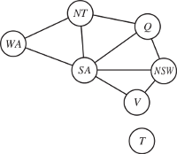

Quelle: [AIMA 3rd ed.](http://aima.cs.berkeley.edu)

- Knoten: Variablen
- Kanten: Constraints

## Constraints – Aritäten

- **unär**: betrifft einzelne Variablen Beispiel: $\operatorname{WA} \neq red$
- **binär**: betrifft Paare von Variablen Beispiel: $\operatorname{WA} \neq \operatorname{NT}$
- **höhere Ordnung**: betrifft 3 oder mehr Variablen
- **Präferenzen**: “soft constraints” Beispiel: “rot ist besser als grün”

Abbildung über Gewichtung => Constraint-Optimierungsproblem (COP)

## Constraints – Wertebereiche

- **Endliche Domänen**: $d$ Werte => $O(d^n)$ mögliche Zuweisungen (exponentiell in der Zahl der Variablen)
- **Unendliche Domänen**: reelle Zahlen, natürliche Zahlen => Keine Auflistung der erlaubten Wertekombinationen mehr möglich => Übergang zu Gleichungen/Ungleichungen: $job_1+5<job_2$
  - lineare Constraints
  - nichtlineare Constraints

**Historische Unterscheidung**:

- **Constraint Satisfaction**: endliche Domänen, kombinatorische Methoden
- **Constraint Solving**: unendliche Domänen

## CSP sind überall …

- Stundenpläne (Klassen, Räume, Zeiten)
- Konfiguration (Computer, Autos, …)
- Fahrpläne (Zug, Flug, …)
- Planung von komplexen Projekten
- Sudoku :-)
- …

# Backtracking und Heuristiken

## Endliche Domänen: Formulierung als Suchproblem

```python
def Backtracking-Search(csp):
    return Backtrack({}, csp)
```

```python
def Backtrack(assignment, csp):
    if complete(assignment): return assignment

    var = SELECT-UNASSIGNED-VARIABLE(csp, assignment)

    for value in ORDER-DOMAIN-VALUES(csp, var):
        if consistent(value, var, assignment, csp):
            assignment += {var = value}

            if INFERENCE(csp, assignment, var) != failure:
                result = Backtrack(assignment, csp)
                if result != failure: return result

            assignment -= {var = value}

    return failure
```

Schrittweise Variablen Werte zuweisen, notfalls Backtracking

## BT-Suche für CSP am Beispiel

Quelle: [AIMA 3rd ed.](http://aima.cs.berkeley.edu)

## BT-Suche für CSP am Beispiel (cnt.)

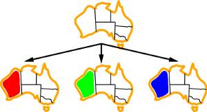

Quelle: [AIMA 3rd ed.](http://aima.cs.berkeley.edu)

## BT-Suche für CSP am Beispiel (cnt.)

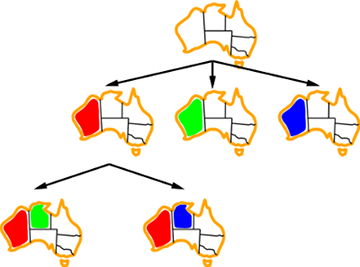

Quelle: [AIMA 3rd ed.](http://aima.cs.berkeley.edu)

## BT-Suche für CSP am Beispiel (cnt.)

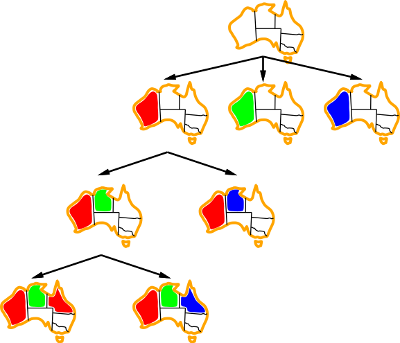

Quelle: [AIMA 3rd ed.](http://aima.cs.berkeley.edu)

## Verbesserung der Suche durch Heuristiken

```python
def Backtrack(assignment, csp):
    if complete(assignment): return assignment

    var = SELECT-UNASSIGNED-VARIABLE(csp, assignment)

    for value in ORDER-DOMAIN-VALUES(csp, var):
        if consistent(value, var, assignment, csp):
            assignment += {var = value}

            if INFERENCE(csp, assignment, var) != failure:
                result = Backtrack(assignment, csp)
                if result != failure: return result

            assignment -= {var = value}

    return failure
```

- `Select-Unassigned-Variable`: Welche Variable zuerst ausprobieren?
- `Order-Domain-Values`: Welchen Wert zuerst ausprobieren?
- `Inference`: Frühzeitiges Erkennen von Fehlschlägen!

## SELECT-UNASSIGNED-VARIABLE: Variablen-Sortierung

Select-Unassigned-Variable

**Minimum Remaining Values (MRV)**:

- Wähle Variable mit wenigsten freien Werten (die am meisten eingeschränkte Variable)

  => reduziert den Verzeigungsgrad

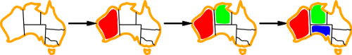

Quelle: [AIMA 3rd ed.](http://aima.cs.berkeley.edu)

## SELECT-UNASSIGNED-VARIABLE: Gleichstand bei MRV

Select-Unassigned-Variable

**Gradheuristik**: Erweiterung von *MRV* bei Gleichstand

- Wähle Variable mit meisten Constraints auf offene (noch nicht zugewiesene) Variablen

  => reduziert den Verzeigungsgrad in späteren Schritten

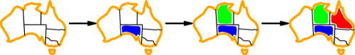

Quelle: [AIMA 3rd ed.](http://aima.cs.berkeley.edu)

## ORDER-DOMAIN-VALUES: Werte-Sortierung

Order-Domain-Values

**Least Constraining Value (LCV)**

- Wähle Wert, der für verbleibende Variablen die wenigsten Werte ungültig macht

  => verringert die Wahrscheinlichkeit für Backtracking

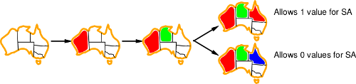

Quelle: [AIMA 3rd ed.](http://aima.cs.berkeley.edu)

# Forward Checking und Constraint Propagation

## Problem bei BT-Suche

Zuweisung eines Wertes an Variable $X$:

- Passt zu aktueller Belegung
- Berücksichtigt aber nicht **restliche** Constraints => macht weitere Suche u.U. unmöglich/schwerer

**Lösung**: Nach Zuweisung alle nicht zugewiesenen Nachbarvariablen prüfen

## INFERENCE: Vorab-Prüfung (Forward Checking)

Inference

Nach Zuweisung eines Wertes an Variable $X$:

- Betrachte alle nicht zugewiesenen Variablen $Y$:
  - Falls Constraints zw. $X$ und $Y$, dann …
  - … entferne alle inkonsistenten Werte aus dem Wertebereich von $Y$.

Quelle: [AIMA 3rd ed.](http://aima.cs.berkeley.edu)

Tafelbeispiel Forward Checking (WA=red, Q=green)

## Forward Checking findet nicht alle Inkonsistenzen!

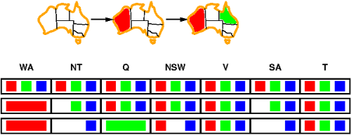

Quelle: [AIMA 3rd ed.](http://aima.cs.berkeley.edu)

- Nach $\{WA=red, Q=green\}$ bleibt für $NT$ und $SA$ nur noch $blue$
- $NT$ und $SA$ sind aber benachbart

## Kantenkonsistenz

- Forward Checking erzeugt Konsistenz für alle Constraints der **gerade betrachteten (belegten) Variablen**.
- Idee: Ausdehnen auf alle Kanten … => Einschränken der Wertemengen

## Definition Kantenkonsistenz (Arc Consistency)

> Eine Kante von $X$ nach $Y$ ist “konsistent ”, wenn für jeden Wert $x \in D_X$ und für alle Constraints zwischen $X$ und $Y$ jeweils ein Wert $y \in D_Y$ existiert, so dass der betrachtete Constraint durch $(x,y)$ erfüllt ist.

Ein CSP ist kanten-konsistent, wenn für alle Kanten des CSP Konsistenz herrscht.

## Beispiel Kantenkonsistenz

$V = \{a,b,c,d,e\}$

$\mathrm{C} = \{((a,b), \ne), ((b,c), \ne), ((a,c), \ne), ((c,d), =), ((b,e), <)\}$

$D_a=D_b=D_c=\{1,2,3\}$, $D_d=\{1,2\}$, $D_e=\{1,2,3\}$

Tafelbeispiel Kantenkonsistenz

Einschränkung der Ausgangswertemengen (kanten-konsistent)

$D_a=\{1,2,3\}$, $D_b=\{1,2\}$, $D_c=\{1,2\}$, $D_d=\{1,2\}$, $D_e=\{2,3\}$

=> Kantenkonsistenz ist nur **lokale** Konsistenz!

*Anmerkung*: $((a,b), \ne)$ ist Kurzform für $\left((a,b), \{(x,y) \in D_a \times D_b \;|\; x \ne y\}\right)$

## AC-3 Algorithmus: Herstellen von Kantenkonsistenz

```python
def AC-3(csp):
    queue = new Queue(csp.arcs)
    while not queue.isEmpty():
        (x,y) = queue.dequeue()
        if Revise(csp,x,y):
            if D_x.isEmpty(): return false
            for z in x.neighbors():
                queue.enqueue(z,x)
    return true
```

```python
def Revise(csp, x, y):
    revised = false
    for v in D_x:
        if not (any w in D_y and csp.C_xy(v,w)):
            D_x.remove(v)
            revised = true
    return revised
```

*Anmerkung*: Die Queue in AC-3 ist wie eine Menge zu behandeln. AC-3 hat eine Laufzeit von $O(d^3n^2)$ ($n$ Knoten, maximal $d$ Elemente pro Domäne). Leider findet auch AC-3 nicht alle Inkonsistenzen … (NP-hartes Problem).

*Hinweis*: In gewisser Weise kann man Forward Checking als ersten Schritt bei der Herstellung von Kantenkonsistenz interpretieren.

## Einsatz des AC-3 Algorithmus

1. Vorverarbeitung: Reduktion der Wertemengen *vor* BT-Suche
   - Nach AC-3 evtl. bereits Lösung gefunden (oder ausgeschlossen)
2. Propagation: Einbetten von AC-3 als Inferenzschritt in BT-Suche (**MAC** – Maintaining Arc Consistency)
   - Nach jeder Zuweisung an $X_i$ Aufruf von AC-3-Variante:
     - Initial nur Kanten von $X_i$ zu allen noch nicht zugewiesenen Nachbarvariablen
   - Anschliessend rekursiver Aufruf von BT-Suche

# Zusammenfassung

## tl;dr

- Definitionen und Begriffe:
  - Variable, (un-) endliche Domänen, Wertemenge
  - Constraint, Arität, CSP
  - Zuweisung, Lösung, …
- Lösung von CSP mit endlichen Domänen mit Hilfe der BT-Suche
- Verbesserung der BT-Suche mit Heuristiken: MRV, Gradheuristik, LCV
- Anwendung von Forward Checking und …
- … die Erweiterung auf alle Kanten: AC-3, Kantenkonsistenz

**Nächste Woche**: Entscheidungsbäume: CAL2, Pruning

## Literatur zum Weiterlesen

- Russell, Norvig: “Artificial Intelligence: A Modern Approach, 3rd ed.”
  - CSP, AC3: Abschnitte 6.1 und 6.2
- Kumar: “Algorithms for Constraint Satisfaction Problems: A Survey”, AI Magazine 13 (1992), Nr. 1, S. 32–44
- Bartak: “Theory and Practice of Constraint Propagation”, Proceedings of the 3rd Workshop on Constraint Programming for Decision and Control, 2001

## Lernziele – Nach dieser Vorlesung sollten Sie …

### Kennen (K1)

- Definitionen: Variable, Domäne, Constraint, Arität, CSP, Zuweisung

### Verstehen (K2)

- Forward Checking (*FC*)
- Erweiterung von *FC* auf alle Kanten: *Kantenkonsistenz*
- Kantenkonsistenz bedeutet nicht globale Konsistenz

### Anwenden (K3)

- Formulierung von CSP
- Lösung von CSP mit endlichen Domänen mit Hilfe der BT-Suche
- Verbesserung der BT-Suche mit Heuristiken: MRV, Gradheuristik, LCV
- AC-3 Algorithmus

## Diese Fragen sollten Sie beantworten können …

### CSP und BT-Suche

- Definieren Sie in eigenen Worten die Begriffe Constraint, CSP, Lösung eines CSP, Kantenkonsistenz.
- Wieviele Lösungen für das Karteneinfärbungsproblem (in der VL besprochenes Beispiel mit Australien) gibt es?
- Wie kann mit Tiefensuche und Backtracking (BT-Search) eine Lösung für ein CSP gefunden werden?
- Formulieren Sie das CSP für die Stundenplanung. Es gibt eine feste Anzahl an Kursen, Dozenten und Seminarräumen sowie mögliche Startzeitpunkte für die Kurse. Jeder Kurs dauert 90 Minuten. Jeder Dozent betreut mehrere Kurse.

### Verbesserungen

- Welche Verbesserungen kennen Sie für die BT-Suche bei CSP? Wie arbeiten diese?
- Erklären Sie, warum es sinnvoll ist, einerseits die am *meisten eingeschränkte Variable* zu wählen, aber andererseits den am *wenigsten beschränkenden Wert* zu wählen.
- Was ist der Unterschied im Ergebnis zwischen Forward Checking und AC-3?
- Was ist ein sogenannter `Alldiff`-Constraint?
- Wie können Sie einen `Alldiff`-Constraint über mehrere Variablen in eine Menge äquivalenter binärer Constraints umformulieren?

### Kantenkonsistenz

- Erklären Sie den Begriff “Kantenkonsistenz”.
- Warum müssen bei AC-3 nach dem Entfernen von Werten aus der Domäne einer Variablen alle Constraints von anderen Variablen zu der aktuell betrachteten Variable erneut untersucht werden?
- Kann AC-3 für ein CSP eine Lösung finden?